# Module 4 Assignment

### Looking at bycatch of other taxa as effort for shark catching increases

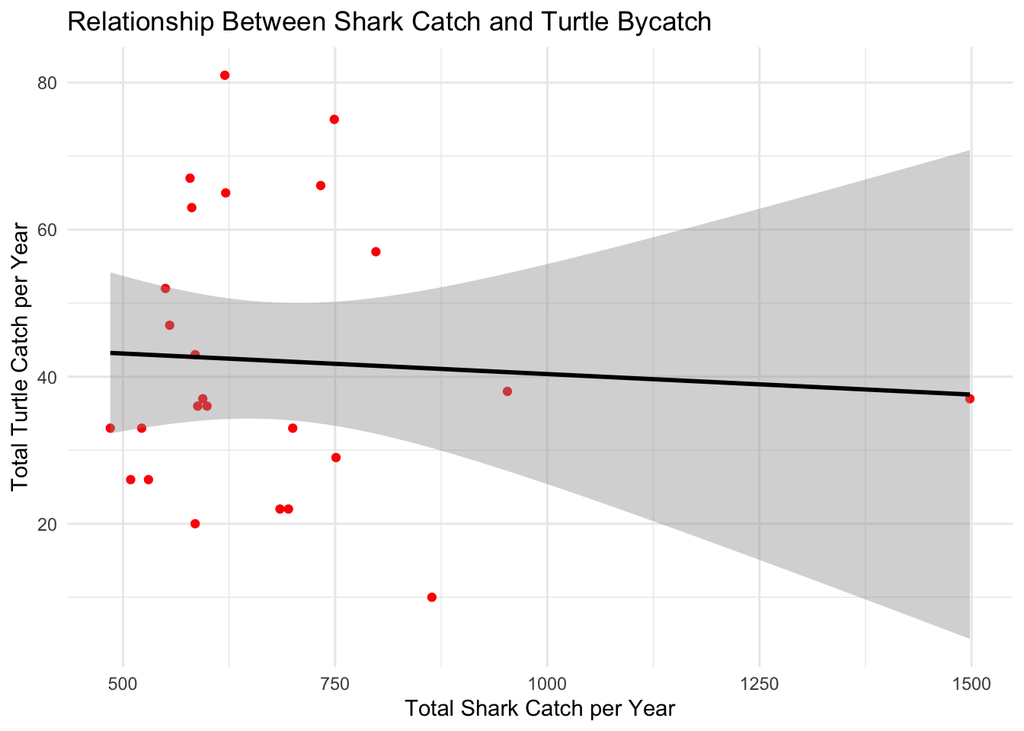

```r
# Summarise total shark catch per year
shark_yearly <- shark_catch_long |>
  filter(Area != "Grand Total") |>
  group_by(Year) |>
  summarise(SharkTotal = sum(Nos, na.rm = TRUE))

# Summarise total turtle catch per year
turtle_yearly <- turtle_catch_long |>
  filter(Area != "Grand Total") |>
  group_by(Year) |>
  summarise(TurtleTotal = sum(Nos, na.rm = TRUE))  # Sum turtle catches for each year

# Merge the two summaries into one table using Year as the key
bycatch_data <- left_join(shark_yearly, turtle_yearly, by = "Year")
# Now we have one row per year, with total shark and turtle catches side by side

# Plotting total turtle catch vs. shark catch per year
ggplot(bycatch_data, aes(x = SharkTotal, y = TurtleTotal)) +
  geom_point(color = "red", size = 1.5) +               # Add points for each year
  geom_smooth(method = "lm", se = TRUE, color = "black") + # Add linear regression line with confidence interval
  theme_minimal() +                                        # Use clean minimal theme
  labs(
    title = "Relationship Between Shark Catch and Turtle Bycatch",
    x = "Total Shark Catch per Year",
    y = "Total Turtle Catch per Year"
  )
```

The scatterplot illustrates the relationship between total shark catch and total turtle catch per year.Each point represents a single year, and the trendline indicates a very slight negative relationship between the two variables. However, the broad confidence interval suggests high variability and low statistical confidence in this trend. Overall, there is no strong evidence to suggest that increases in shark catch lead to increases in turtle bycatch.